## Problem 3

This is the probability that at most one parent have contracted influenza. So the probability either the mother alone, the father alone, or neither parent has contracted the flu.

Let F be the event that the father contracted cryptosporidiosis and M be the event that the mother contracted cryptosporidiosis. Using this notation, we are given P($F \cup M$) = 0.21, P($F \cap M$) = 0.05, and P(F) = 0.09. Note that the event in which either the mother or the father has contracted cryptosporidiosis is denoted by $F \cup M$, or equivalently, the event in which least one parent contracted the disease. We are given P($F \cup M$) is 0.21.

Using the same notation as in part b,

$M \cap F^c$ = {mother contracted cryptosporidiosis, but father has not}

We know that

P($M \cap F^c) = P(M) - P(M \cap F) = 0.17 - 0.05 = 0.12$

$P(F \cup M) = P(F) + P(M) - P(F \cap M)$.  
Thus, solving for P(M), we get

$P(M) = P(F \cap M) + P(F \cap M) - P(F) = 0.21 + 0.05 - 0.09 = 0.17$

$P(F^c \cap M^c) = 1 - P(F \cup M) = 1 - 0.21 = 0.79$

$P(F \cap M^c) = P(F) - P(M \cap F) = 0.09 - 0.05 = 0.04$

## Problem 7

1. Since h(x)>0 for all x,$\sum h(i)>0$ and thus p(x)>0.
2. $$\begin{align*}
   \sum^{I}_{x=1}p(x) &= \sum^{I}_{x = 1} h(x)/ \sum^{I}_{i=1} h(i)\\
   &= \frac{\sum h(x)}{\sum h(x)}\\
   &= 1
   \end{align*}$$

So p(x) is a valid pmf.

## Problem 8

1. For all x, h(x) >0 and c>0, thus f(x)>0
2. $$\begin{align*}
   \int ^{\infty }_{-\infty }f\left( x\right) &=\int ^{\infty }_{-\infty }h\left( x\right) /c \\
   &= \dfrac {\int ^{\infty }_{-\infty }h\left( x\right) }{\int ^{\infty }_{-\infty }h\left( x\right) } \\
   &=1
   \end{align*}$$

## Problem 9

1. $$\begin{align*}
   \int^{1}_{0}f(x)dx &= kx |^{1}_{0} \\
   &= k =1
   \end{align*}$$

So k = 1.

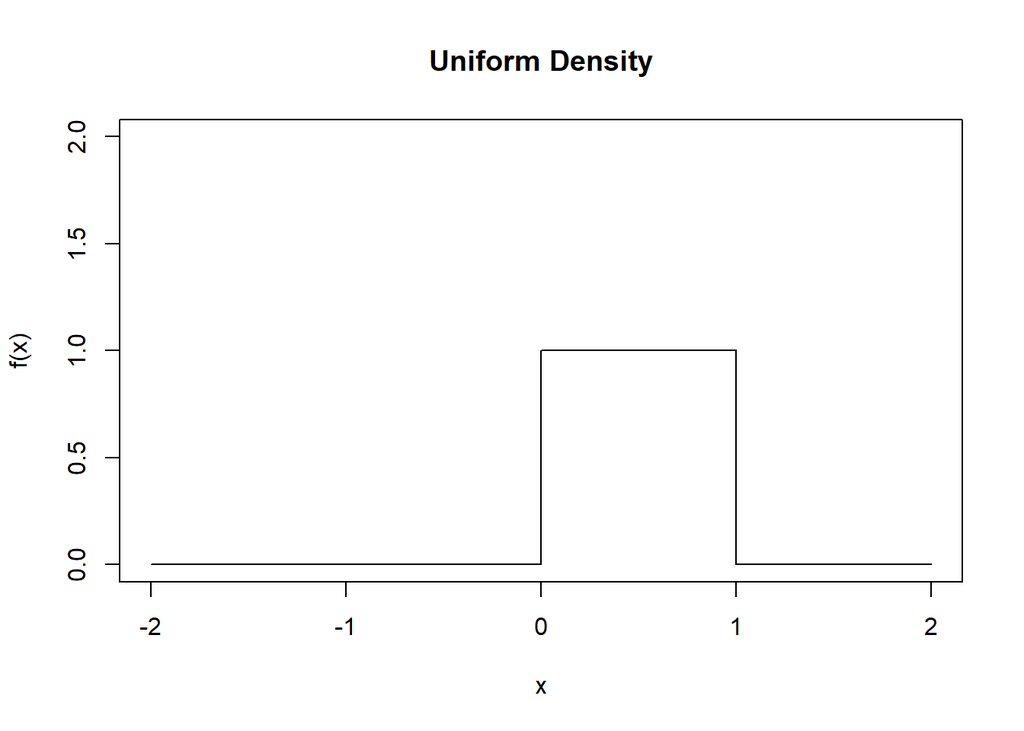

```r
x <- c(-2, 0, 0, 1, 1, 2)
y <- c(0, 0, 1, 1, 0, 0)
plot(x,y, "l", xlim = c(-2,2), ylim = c(0,2),
main = "Uniform Density", xlab = "x", ylab = "f(x)")
```

$p=\int ^{0.7}_{0.1}f\left( x\right) dx=0.7-0.1=0.6$

```r
lb <- 0.1 # Lowerbound
ub <- 0.7 # Upperbound
punif(ub) - punif(lb)
```

```
## [1] 0.6
```

For general a and b, we have P = b - a.

$$\begin{align*}
F\left( x\right) &=p( X < x) \\
&=\int ^{x}_{0}f\left( y\right) dy \\
&= y|^{x}_{0} = x
\end{align*}$$

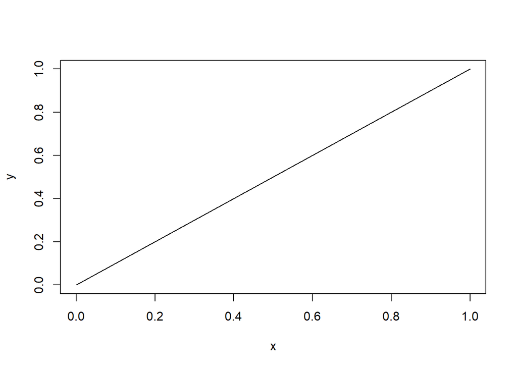

```r
x = c(0,1)
y = c(0,1)
plot(x,y,'l')
```

Let m denote the median. By definition of median, P(X < m) = F(m) = 0.5. From part (d) above, we know that F(x) = x, implying that m = 0.5. In the context of our problem, the median of 0.5 means that the probability of individuals having less than 50% of their skin covered in freckles is 0.5.

The 95th percentile is the value x such that F(x) = 0.95. From part (d), we know that F(x) = x, implying that the 95th percentile is given by x = 0.95. In the context of this problem, the 95th percentile means that the probability of a randomly drawn subject having less that 95% of their skin covered in freckles is 0.95.

The uniform distribution is probably not a reasonable distribution for the proportion of freckles on subjects in a given population as it should not be equally likely to have over 50% of your skin covered in freckles as it is to have less than 50% of your skin covered in freckles.

## Problem 12

1. $e^x > 0 for all x, and 1+ e^x >0, thus pdf > 0 .$
2. $$\begin{align*}
   \int^{\infty}_{-\infty } \frac{e^{-x}}{(1+e^{-x})^2}dx &= \int^{1}_\infty - \frac{1}{u^2}du \\
   &= \frac{1}{u} | ^1_\infty \\&= 1-0 =1
   \end{align*}$$

Same as a:
$$F(x) = \frac{1}{u}|^{1+e^{-x}}_\infty = \frac{1}{1+e^{-x}}$$

$$F(0) = \frac{1}{e^{-0}} = 1/2$$
So 0 is the median of this distribution.In the context of this problem, a median of 0 means that the median cancer risk is 0.

To find to value x such that F(x) = p:
$$\begin{align*}
\frac{1}{1+e^{-x}} &= p \\
e^{-x} &= 1/p -1\\
x &= log(\frac{p}{1-p})
\end{align*}$$

## Problem 14

$$\begin{align*}
\int^1_0 cx^k dx &= \frac{c}{k+1}x^{k+1} | ^1_0 \\
&= \frac{c}{k+1} =1\\
c &= k+1
\end{align*}$$

2. $$\begin{align*}
   F(x) &= \int^x_0 (k+1) y ^k dy \\ &= x^{k+1} |^x_0 \\
   &= x^{k+1}
   \end{align*}$$

$p = x^{k+1} \to x = p^{1/(k+1)}$

4. $$P(a<x<b) = \int ^b_a (k+1)x^k dx \\ = x^{k+1} | ^b_a = b^{k+1} - a^{k+1}$$

## Problem 15

$1 = \int ^{\infty}_0 cexp(\frac{-x}{2.5})dx = -2.5 cexp(\frac{-x }{2.5})|^\infty_0 =2.5c$  
So we know c = 2/5.

$F(x) =\int^x_0 \frac{1}{2.5} exp(\frac{-y}{2.5})dy = -exp(\frac{-y}{2.5}) |^x_0 = 1- exp(-x/2.5)$

$S(x) = 1 - F(x) = exp(-x/2.5)$

$S(11) = exp(\frac{-11}{2.5}) = 0.012$

$F(x) = 0.5 \to 0.5 = exp(\frac{-x }{2.5}) \to x = -2.5log0.5$